# Time Series: A First Course with Bootstrap Starter

# Lesson 10-11: Iterative Forecasting

- With a fitted model we can compute forecasts, backcasts, and missing values using the normal equations.
- The fitted model provides us with estimated autocovariances, which are needed in the normal equations.

## Proposition 10.11.3

- The $h$-step-ahead predictor can be calculated in terms of $j$-step-ahead predictors, for $1 \leq j < h$.
- Get the $2$-step-ahead from the $1$-step-ahead predictor as follows:
  $$\begin{align*}
  \widehat{X}_{n+1} & = \underline{\varphi}_n^{\prime} \underline{X}_n
  \\
  \widehat{X}_{n+2} & = \underline{\varphi}_{n+1}^{\prime} \,
  \left[ \begin{array}{c} \underline{X}_n \\ \widehat{X}_{n+1}
  \end{array} \right].
  \end{align*}$$
- Continue on iteratively to get the $h$-step-ahead: append the forecast and apply the next one-step-ahead predictor.

## Remark 10.11.4. Iterative Forecasting is Efficient

- Direct calculation from the normal equations of forecasts would be expensive, because we have to invert a $n$-dimensional covariance matrix.
- The one-step-ahead predictors $\underline{\varphi}_n$ are efficiently computed in the Durbin-Levinson algorithm, so the iterative approach of Proposition 10.11.3 is faster.

## Paradigm 10.11.7. Forecasting an Integrated Process

- Suppose that $\{ X_t \}$ is a nonstationary time series that is integrated, and we want to forecast it.
- Suppose that $\delta (B) = 1 - \sum_{j=1}^d \delta_j B^j$ is a *differencing* polynomial that reduces $\{ X_t \}$ to stationarity, i.e.,
  $$Y_t = \delta (B) X_t = X_t - \sum_{j=1}^d \delta_j X_{t-j}$$
  is a stationary process.
- Then we can forecast $\{ X_t \}$ as follows: forecast the $\{ Y_t \}$ series, obtaining $\widehat{Y}_{n+1}$, and use the formula
  $$\widehat{X}_{n+1} = \sum_{j=1}^d \delta_j X_{n+1-j} + \widehat{Y}_{n+1}.$$
- This works when $X_n, \ldots, X_{n+1-d}$ are observed.

## Exercise 10.61. Recursive Forecasting of Mauna Loa

- We will forecast the Mauna Loa time series.
- We first fit an AR(p) model to the annual differences of the logged data.

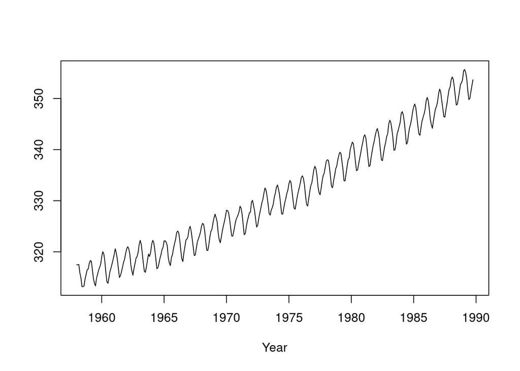

```r
polymul <- function(a,b)
{
    bb <- c(b,rep(0,length(a)-1))
    B <- toeplitz(bb)
    B[lower.tri(B)] <- 0
    aa <- rev(c(a,rep(0,length(b)-1)))
    prod <- B %*% matrix(aa,length(aa),1)
    return(rev(prod[,1]))
}

ARMAauto <- function(phi,theta,maxlag)
{
    p <- length(phi)
    q <- length(theta)
    gamMA <- polymul(c(1,theta),rev(c(1,theta)))
    gamMA <- gamMA[(q+1):(2*q+1)]
    if (p > 0)
    {
        Amat <- matrix(0,nrow=(p+1),ncol=(2*p+1))
        for(i in 1:(p+1))
        {
            Amat[i,i:(i+p)] <- c(-1*rev(phi),1)
        }
        Amat <- cbind(Amat[,(p+1)],as.matrix(Amat[,(p+2):(2*p+1)]) +
            t(matrix(apply(t(matrix(Amat[,1:p],p+1,p)),2,rev),p,p+1)))
        Bmat <- matrix(0,nrow=(q+1),ncol=(p+q+1))
        for(i in 1:(q+1))
        {
            Bmat[i,i:(i+p)] <- c(-1*rev(phi),1)
        }
        Bmat <- t(matrix(apply(t(Bmat),2,rev),p+q+1,q+1))
        Bmat <- matrix(apply(Bmat,2,rev),q+1,p+q+1)
        Bmat <- Bmat[,1:(q+1)]
        Binv <- solve(Bmat)
        gamMix <- Binv %*% gamMA
        if (p <= q) { gamMix <- matrix(gamMix[1:(p+1),],p+1,1)
            } else gamMix <- matrix(c(gamMix,rep(0,(p-q))),p+1,1)
        gamARMA <- solve(Amat) %*% gamMix
    } else gamARMA <- gamMA[1]

    gamMA <- as.vector(gamMA)
    if (maxlag <= q) gamMA <- gamMA[1:(maxlag+1)] else gamMA <- c(gamMA,rep(0,(maxlag-q)))
    gamARMA <- as.vector(gamARMA)
    if (maxlag <= p) gamARMA <- gamARMA[1:(maxlag+1)] else {
    for(k in 1:(maxlag-p))
    {
        len <- length(gamARMA)
        acf <- gamMA[p+1+k]
        if (p > 0) acf <- acf + sum(phi*rev(gamARMA[(len-p+1):len]))
        gamARMA <- c(gamARMA,acf)
    } }
    return(gamARMA)
}

mau <- read.table("mauna.dat",header=TRUE,sep="")
mau <- ts(mau,start=1958,frequency=12)
mau.gr <- diff(log(mau),lag=12)
plot(mau,ylab="",xlab="Year")
```

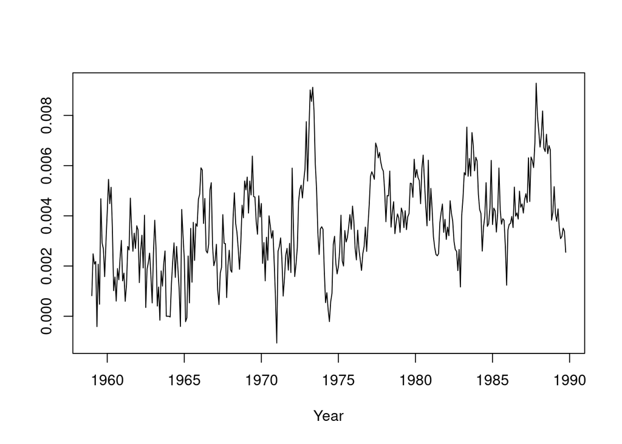

```r
plot(mau.gr,ylab="",xlab="Year")
```

- We also examine the pacf.

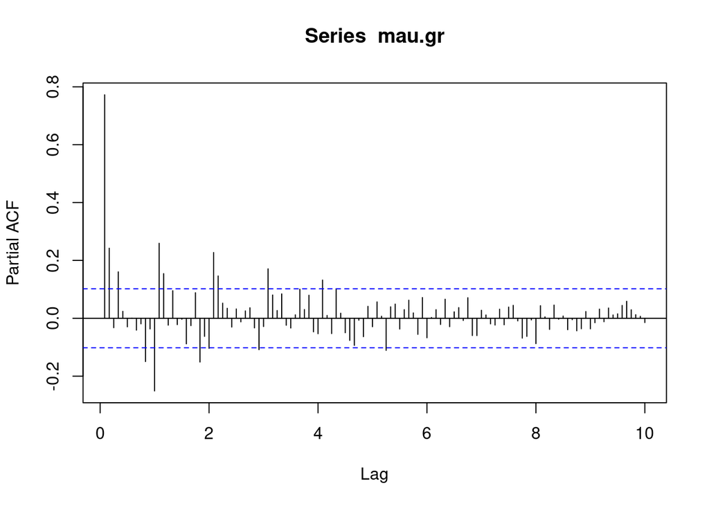

```r
delta <- c(1,rep(0,11),-1)
d <- length(delta)-1
n <- length(mau.gr)
mau.pacf <- pacf(mau.gr,lag.max=120)
```

- By inspection of the pacf plot, we choose $p=49$. We fit an AR(49) model using Yule-Walker.

```r
arp.fityw <- function(data,p)
{
    gamma.hat <- acf(data,lag=p,type="covariance",plot=FALSE)$acf[,,1]
    phi <- solve(toeplitz(gamma.hat[1:p]),gamma.hat[2:(p+1)])
    sigma2 <- gamma.hat[1] - sum(phi*gamma.hat[2:(p+1)])
    hess <- sigma2*diag(solve(toeplitz(gamma.hat[1:p])))
    return(list(phi,sigma2,hess))
}

p.hat <- 49
ar.coef <- arp.fityw(mau.gr,p.hat)[[1]]
sigma2 <- arp.fityw(mau.gr,p.hat)[[2]]
```

- Then we forecast $50$ steps ahead. The basic pattern gets extended.

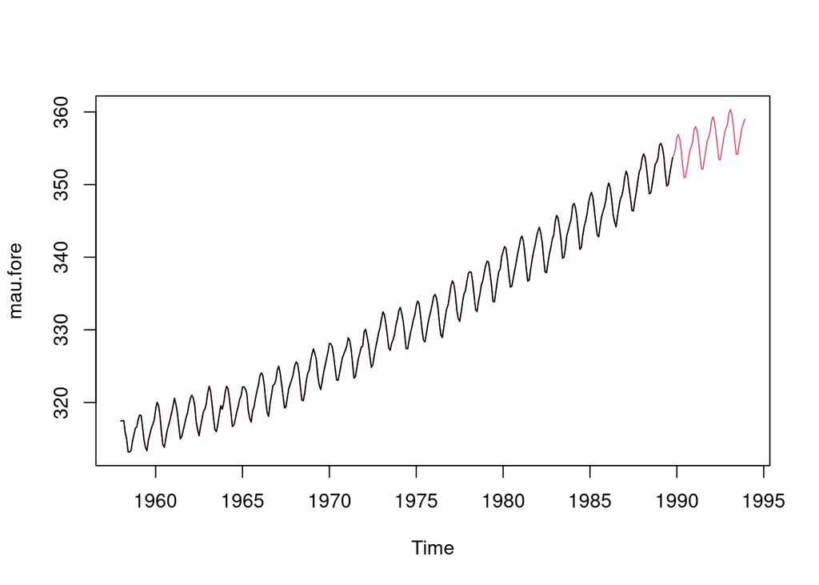

```r
pred.k <- function(gamma,max.lag)
{
    kappa.vec <- gamma[2]/gamma[1]
    varphi.vec <- kappa.vec
    if(max.lag > 1) {
    for(k in 2:max.lag)
    {
        schur.new <- gamma[1] - t(varphi.vec) %*% rev(gamma[2:k])
        kappa.new <- (gamma[k+1] - sum(varphi.vec*gamma[2:k]))/schur.new
        kappa.new <- kappa.new[1,1]
        if(abs(kappa.new) < 10^(-15)) kappa.new <- 0
        kappa.vec <- c(kappa.vec,kappa.new)
        varphi.vec <- rev(varphi.vec) - kappa.new * varphi.vec
        varphi.vec <- rev(c(varphi.vec,kappa.new))
    } }
    return(varphi.vec)
}

H <- 50
gamma <- ARMAauto(ar.coef,NULL,n+H)*sigma2
x <- mau.gr
for(k in 1:H)
{
    varphi.vec <- pred.k(gamma,n+k-1)
    cast <- sum(varphi.vec * x)
    x <- c(x,cast)
}
mau.fore <- c(log(mau)[1:d],filter(x,-delta[-1],method="recursive",init=log(mau)[d:1]))
mau.fore <- ts(exp(mau.fore),start=1958,frequency=12)

plot(mau.fore,col=2)
lines(mau)
```